# 学習開始時の英語力と動機づけが学習成果に及ぼす影響

作成:2024-07-23, 最終更新(JST): 2024-07-30 14:33:09

## 背景

- 学習者の英語習熟度が学期終了時にどの程度向上するかを学期開始前に予測できれば、より効果的なカリキュラムや教育方針を立案できる。
  - e.g., 習熟度別クラスの編成、指導介入の目安
- 初年次教育は、非常勤の先生が担当することもある。
  - 学生の傾向などを事前に共有できると有意義

## 先行研究

## 動機づけと学習成果の関係

### Nagle (2018)

- 学習者の動機づけと発音の発達を縦断的に調査
  - 英語母語スペイン語学習者を対象
- 動機づけ：理想L2自己、義務L2自己
- 発音：わかりやすさ、訛り度
- 理想L2自己、義務L2自己ともに、わかりやすさと訛り度を予測しない

### Tsang (2022)

- リスニングの動機づけと四技能の関係を調査
  - 香港で英語を学ぶ小学3年生と4年生を対象
- 相関分析：リスニングの動機づけと四技能の総合得点との間に有意な相関関係（*r* = .40）
- 階層的重回帰分析・パス解析：リスニングの動機づけと四技能の間に直接的な関係はなし

## 学習開始時の英語能力と学習成果

### Ruegg et al. (2024)

- 大学入学時の英語テスト（IELTS、学内の英語テスト）の得点とGPAの関係を調査
  - 主にアジア圏からの留学生（大学）
- 回帰分析：英語テストとGPAに正の関係を確認
  - 英語習熟度が高い学生は、平均してGPAも高い

### Ihlenfeldt & Rios (2023)

- 入学時の英語成績と学習成績の関係に関するメタ分析
  - スクリーニングの結果、32の研究を対象に分析
  - TOEFLやIELTSなどの英語試験とGPAとの間に有意な弱い相関（*r* = .23、95% CI [.18, .28]）

## 先行研究の限界

### 動機づけ

- 研究間：Nagle (2018)では関係がないと報告している一方、Tsang (2022)の相関分析では関係あり
- 研究内：Tsang (2022)では、相関分析を使うと有意な関係が見られるが、階層的重回帰分析及びパス解析を用いると有意な関係が見られない

### 学習者の習熟度

- 1年・半年以下の英語成績の研究の蓄積が少ない
- GPAよりもより具体的な英語成績の伸びとの関連の研究が少ない

## 本研究

## 研究仮説

### R.H. 1: 動機づけの因子得点が高いほど、平均してゲイン得点が高い

### R.H. 2: 学習開始時の英語テストの得点が高いほど、平均してゲイン得点が高い

### R.H. 3: 動機づけの因子得点が高く、学習開始時の得点が高いほど、平均してゲイン得点が高い

## 参加者

- 117名の愛知工科大学に在籍する学生
  - 初年次の必修英語クラスを受講
  - 4月の学期前に受講するComputerized Assessment System for English Communication (CASEC)の得点を元にクラス分け
- データの提供を許可した学生のデータのみ使用

## 調査素材

### 動機づけの質問紙 （Agawa and Takeuchi, 2016）

- 心理的欲求
  - 自律性
  - 有能感
  - 関係性
- **英語学習の動機づけ**
  - 内発的動機付け
  - 外発的動機付け
  - 統合的
  - 同一化 + 取り入れ的
  - 外発的
  - 無動機

## 調査素材

### CASEC

- 読解と聴解からなるテスト。コンピュータ上で受験（1000点満点）。
- CASECでゲイン得点を調査する利点
  - 講義内で対策などは行わない
  - 学生個人で対策ができない（公式の対策本が存在しない）

## 手順

1. 2023年度前期の定期試験としてCASECを実施（2023年8月）
- 再履修クラスの学生は、これ以前にCASECを受けている者もいる
1. 2023年度後期の初回に質問紙を配布（2023年9月）
2. 2023年度後期の定期試験としてCASECを実施（2024年1月）

## 分析

## 分析方法

- 欠損値の代入（多重代入法）
- 探索的因子分析
  - 因子得点を算出するため
- 回帰分析
  - 従属変数：
    - 講義後のCASEC得点 - 講義前のCASEC得点
  - 独立変数：
    - 講義開始前のCASECの得点
    - 因子得点
    - 2要因の交互作用

## 欠損値の処理

### 欠損データの割合

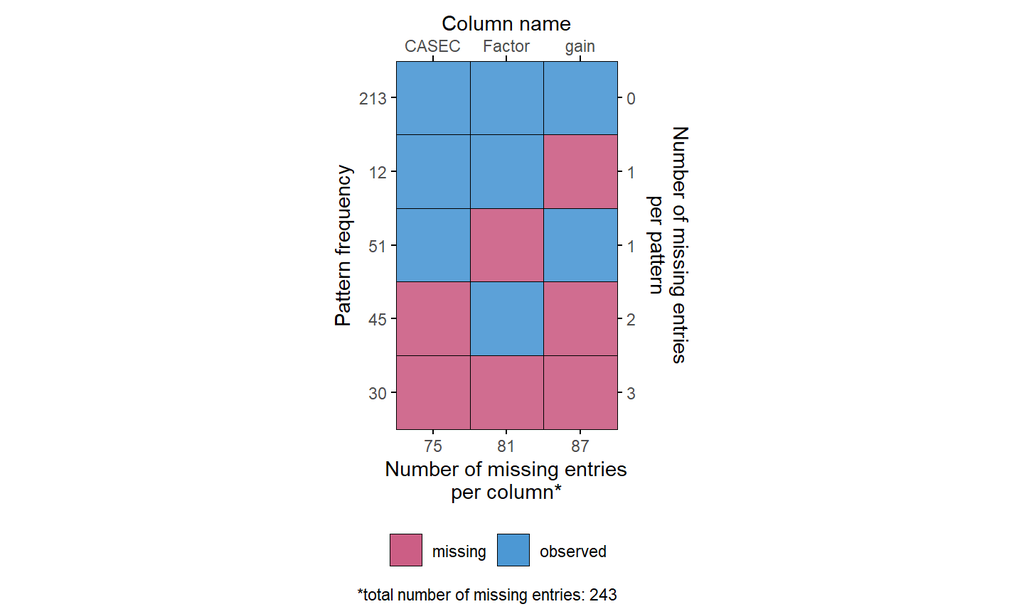

| variable | % |
| --- | --- |
| gain | 24.8 |
| Factor | 23.1 |
| CASEC | 21.4 |

## 欠損値の補完（多重代入法）

### CASEC8月

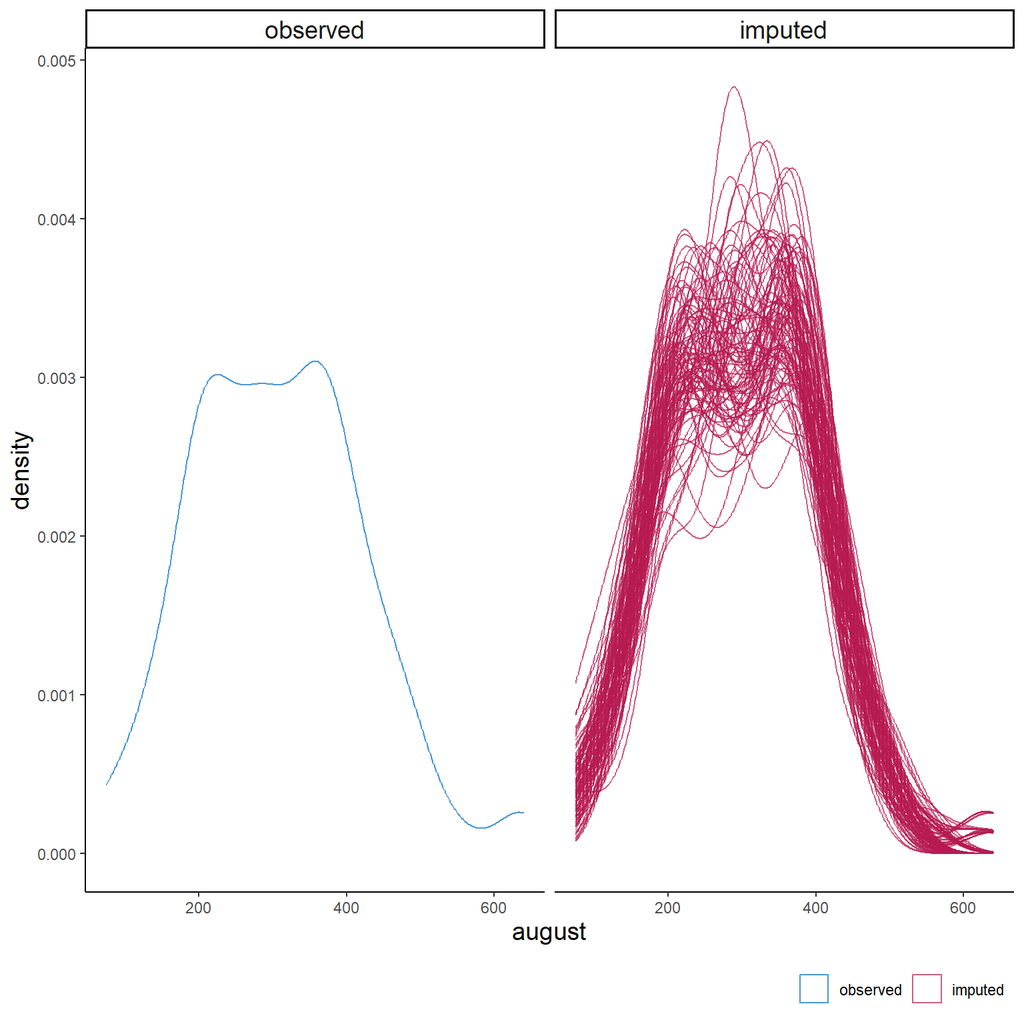

### 8月の因子スコア

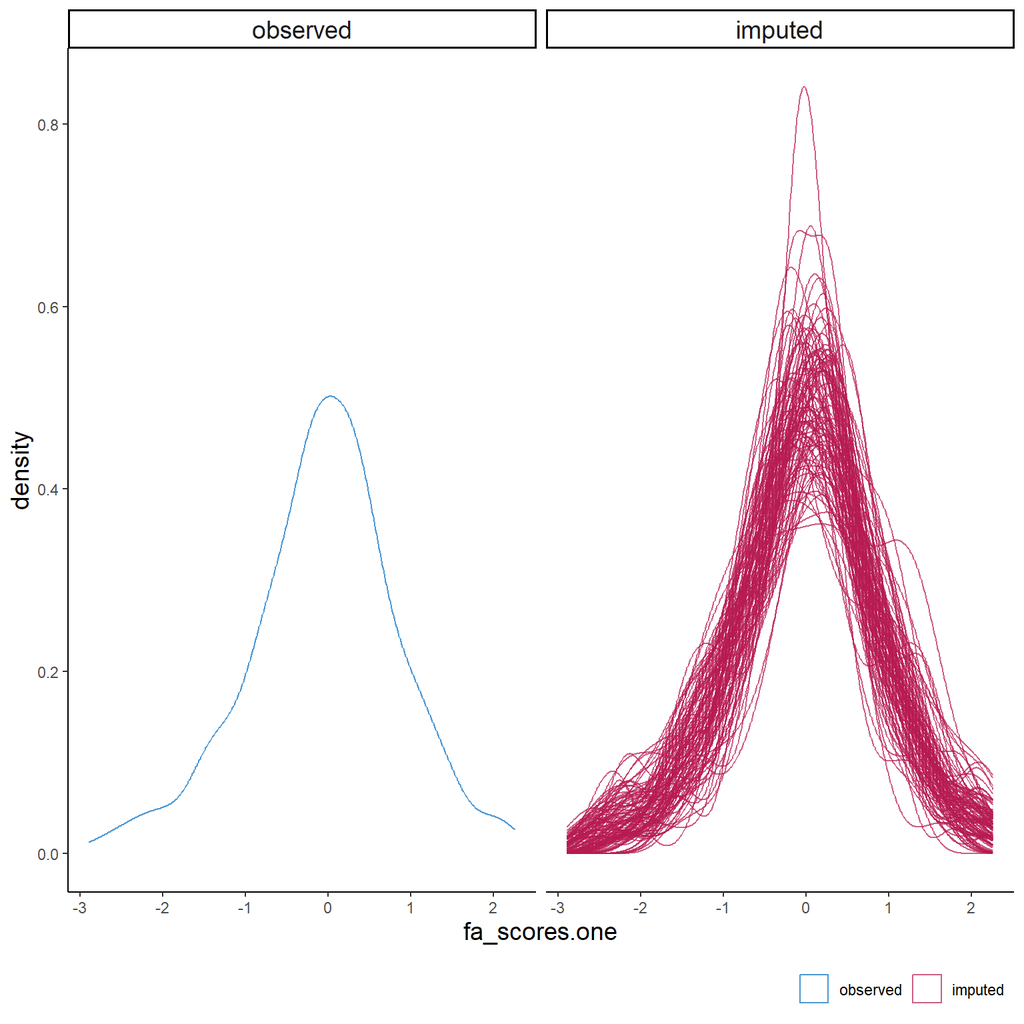

### ゲイン得点

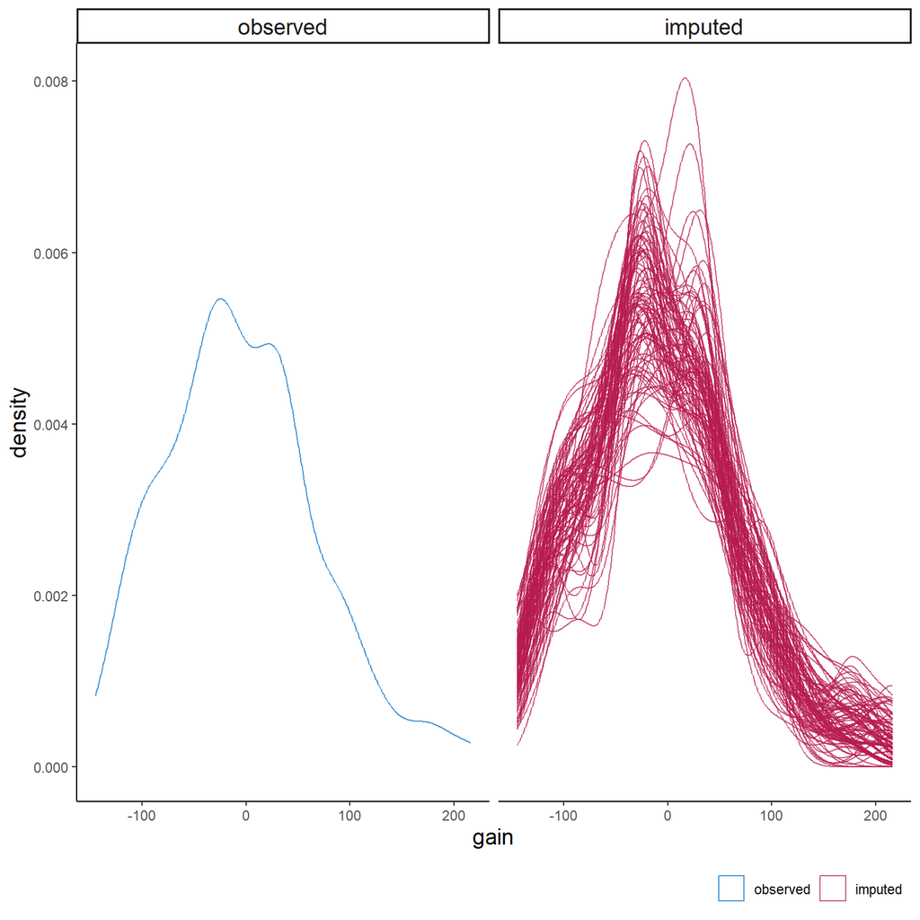

## 混合効果ベイズ回帰

### 事後予測チェック

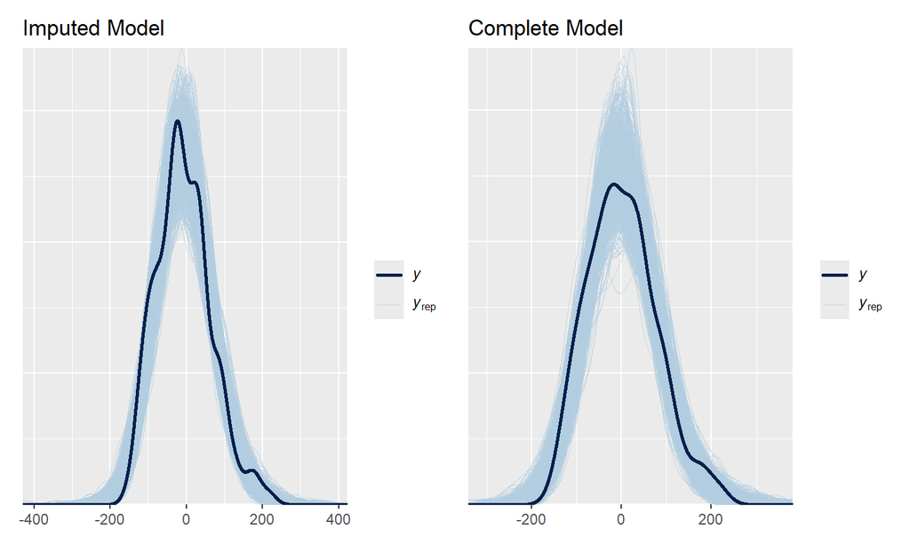

## 結果

- 注. Completeのデータのclass変数の数が10になっているのは（本来は11）、英語中級Eクラスは8月にデータを取得しておらず、NAの値しかないため。

|  | Model 5 [complete] |  | Model 5 [imputed] |  |
| --- | --- | --- | --- | --- |
| Predictors | Estimates | CI (95%) | Estimates | CI (95%) |
| Intercept | -22.92 | -62.58 – 16.14 | -15.57 | -49.73 – 17.07 |
| scaleaugust | -60.92 | -99.33 – -20.46 | -48.12 | -79.85 – -17.54 |
| fa_scores.one | -0.31 | -10.34 – 9.84 | -0.58 | -9.85 – 7.97 |
| scaleaugust:fa_scores.one | -0.41 | -11.68 – 10.81 | -0.22 | -8.29 – 8.02 |
| Random Effects |  |  |  |  |
| σ<sup>2</sup> | 3583.44 |  | 3482.46 |  |
| τ<sub>00</sub> | 3758.29 <sub>class</sub> |  | 2808.87 <sub>class</sub> |  |
| τ<sub>11</sub> | 2888.62 <sub>class.scaleaugust</sub> |  | 1964.02 <sub>class.scaleaugust</sub> |  |
| ρ<sub>01</sub> |  |  |  |  |
| ρ<sub>01</sub> |  |  |  |  |
| ICC | 0.51 |  | 0.45 |  |
| N | 10 <sub>class</sub> |  | 11 <sub>class</sub> |  |
| Observations | 213 |  | 351 |  |
| Marginal R<sup>2</sup> / Conditional R<sup>2</sup> | 0.336 / 0.410 |  | 0.326 / 0.373 |  |

## 作図

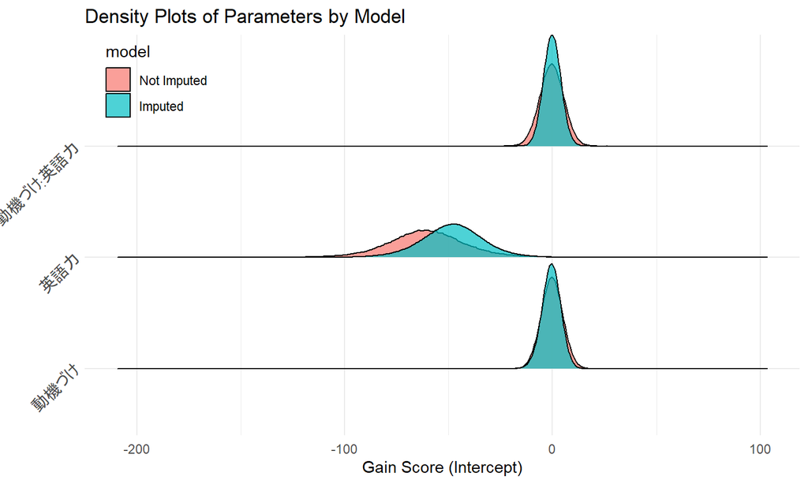

## ランダム効果

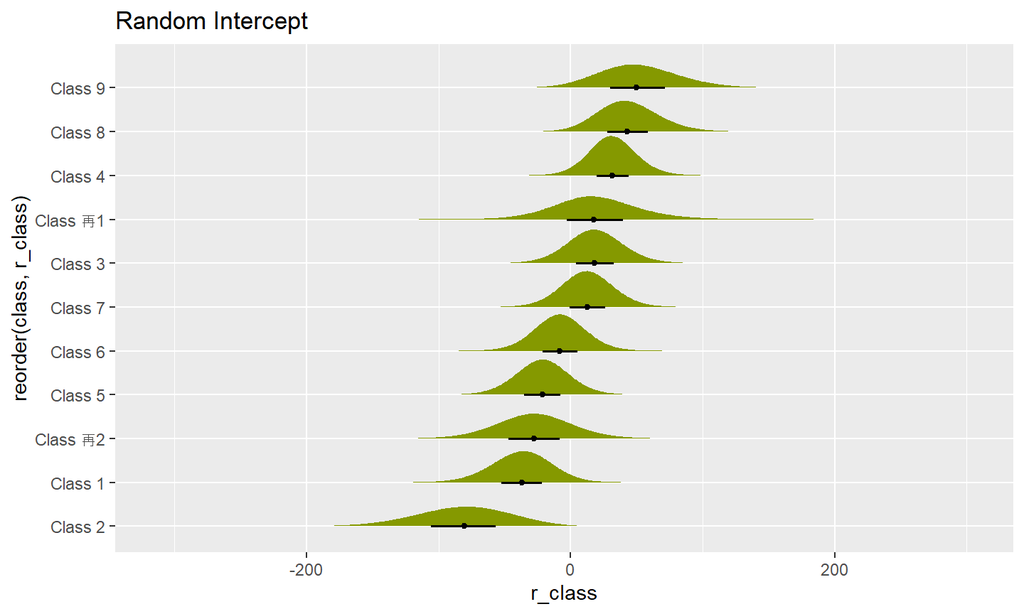

## ランダム効果

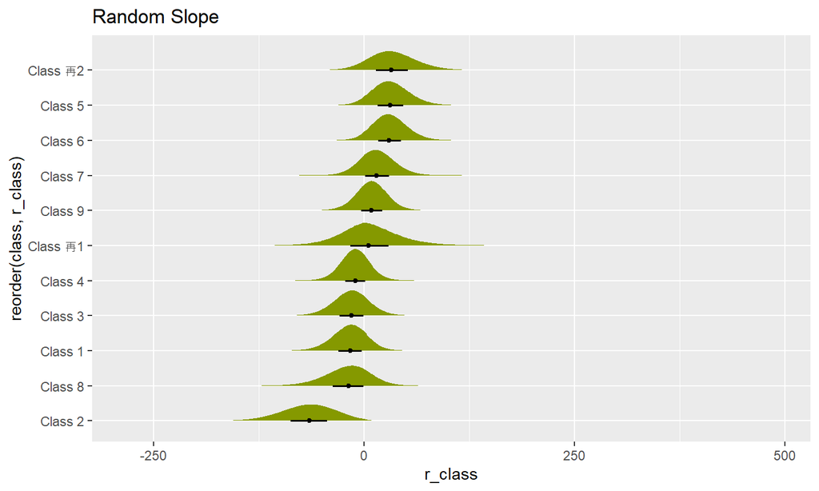

## 作図

- **Note:**
  - 黒の点線は切片を表す。色付きの直線はクラスごとの回帰直線
  - “Class 1” = “Green”,
  - “Class 2” = “Olive”,
  - “Class 3” = “Sand”,
  - “Class 4” = “Rose”,
  - “Class 5” = “Wine”,
  - “Class 6” = “Red”,
  - “Class 7” = “Indigo”,
  - “Class 8” = “Cyan”,
  - “Class 9” = “Teal”,
  - “Class 再1” = “Purple”,
  - “Class 再2” = “Pale Gray”

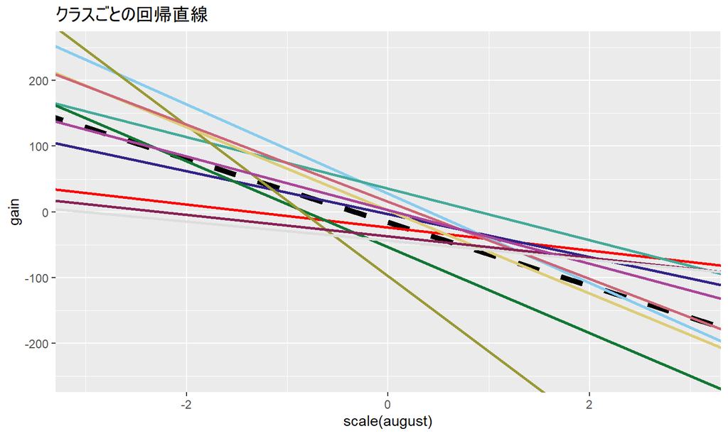

## 結果＆議論

## R.H. 1:

動機づけの因子得点が高いほど、平均してゲイン得点が高い

- **Not Supported**
  - ゲイン得点は0をまたいで分布しており、顕著な関係は得られなかった。
    - 先行研究と一致（Nagle, 2018; Tsang, 2022[回帰分析]）
  - 動機づけは変動しやすい
    - 1時点の動機づけスコアで成績に与える影響を予測するのは困難（引用）

## R.H. 2:

学習開始時の得点が高いほど、平均してゲイン得点が高い

- **Not Supported**
  - 学習開始時の得点とゲイン得点に負の関係が確認
    - クラスごとに係数の値が大きく異なる
      - 習熟度が比較的低いクラスほどその傾向が大きい
  - 平均への回帰という現象
  - 単位取得要件の成績配分に占める割合が比較的小さい

## R.H. 3:

動機づけの因子得点が高く、学習開始時の得点が高いほど、平均してゲイン得点が高い

- Not Supported
  - ゲイン得点は0をまたいで分布しており、顕著な関係は得られなかった。

## 引用文献

- Ihlenfeldt, S. D., & Rios, J. A. (2023). A meta-analysis on the predictive validity of English language proficiency assessments for college admissions. *Language Testing, 40*(2), 276-299.
- Nagle, C. (2018). Motivation, comprehensibility, and accentedness in L2 Spanish: Investigating motivation as a time‐varying predictor of pronunciation development. *The Modern Language Journal, 102*(1), 199-217.
- Ruegg, R., Hoang, H., & Petersen, N. (2024). The influence of English language proficiency test scores on the academic success of ESL undergraduate students. *Educational Research and Evaluation, 29*(3-4), 111-129.
- Tsang, A. (2022). FL listening motivation, interest, linguistic self-confidence, and overall proficiency: A complete double mediation model. *System, 108*, 102833.

## PC Info

```r
# Logical Cores
detectCores()
```

```
## [1] 32
```

```r
# Physical Cores
detectCores(logical = FALSE)
```

```
## [1] 24
```